# Lab 06 - Amanda Freitas

Para realizar esta lista de exercícios, considere a base da dados que está no Moodle. Esta é uma base com dados reais, com os resultados das eleições nacionais de 2010 e 2014 – a mesma da semana passada.

O banco nos permite responder a questão sobre o que explicou o voto no PT no ano de 2014 (PT_2014).

A unidade de análise é a votação por município. Então, 5572 observações. Há, como variáveis explicativas: * o voto no partido em 2010 (PT_2010); * a população das cidades, tanto em nível (pop2014), quanto em logaritmo (ln_pop_2014); * a porcentagem de famílias da cidade que recebem o bolsa família em 2014 (alcance_PBF_2014); * e uma dummy que indica se a cidade está na região Nordeste do país ou não (Nordeste).

Inicialmente, precisamos avaliar se as variáveis explicativas se adequariam a um modelo linear em relação á variável resposta (PT_2014). Para isto, vamos lançar mão de gráficos que nos ajudarão a tomar essa decisão.

Usando o comando a seguir, construa gráficos de dispersão para cada um dos pares de variáveis, alterando a variável x (marcada em vermelho).

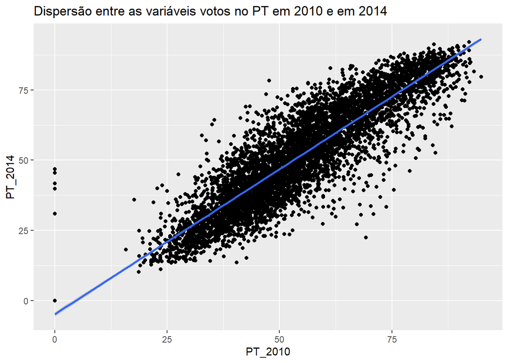

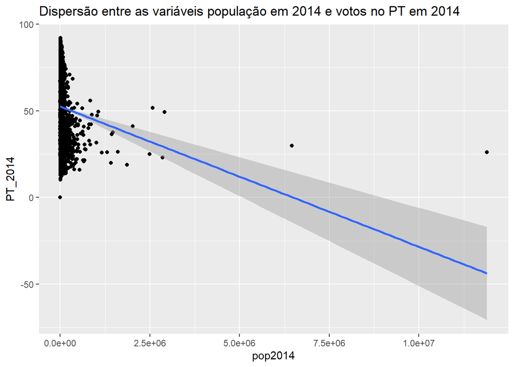

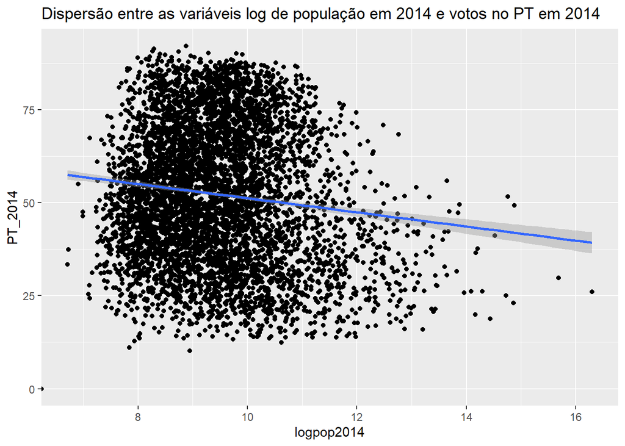

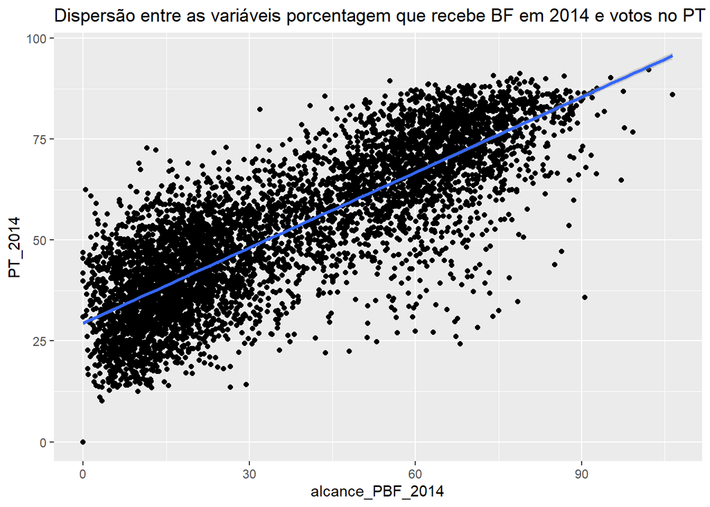

1. Discuta a adequação do modelo linear para cada variável. Determine, assim, as variáveis que entrarão no modelo e sua especificação.

*Modelos lineares assumem que a relação entre duas variáveis é constante ao longo de todos os intervalos, isto é, tem uma relação que pode ser representada por $\alpha + \beta X$. A partir dos gráficos de dispersão, podemos vizualizar uma relação linear entre a variável votos no PT em 2014 e as variáveis votos no PT em 2010, e porcentagem da população que recebe o Bolsa Família. A relação entre votos no PT em 2014 e o log da população parece ter uma relação linear, porém com correlação baixa.*

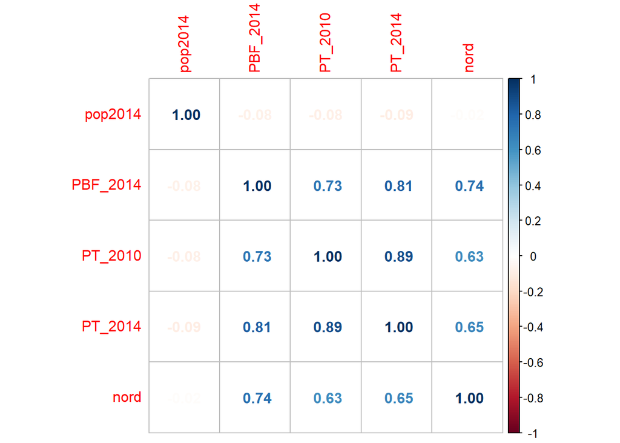

2. Se rodássemos um modelo bivariado apenas com a variável transformada, como interpretaríamos o coeficiente deste modelo?

|  | *Dependent variable:* |  |
| --- | --- | --- |
|  | PT_2014 |  |
|  | (1) | (2) |
| PT_2010 | 1.0330*** |  |
|  | (0.0071) |  |
| alcance_PBF_2014 |  | 0.6225*** |
|  |  | (0.0059) |
| Constant | -4.8354*** | 29.4193*** |
|  | (0.4099) | (0.2607) |
| Observations | 5,572 | 5,572 |
| R<sup>2</sup> | 0.7903 | 0.6639 |
| Adjusted R<sup>2</sup> | 0.7903 | 0.6638 |
| Residual Std. Error (df = 5570) | 8.4791 | 10.7348 |
| F Statistic (df = 1; 5570) | 20,993.7700*** | 11,002.7500*** |
| *Note:* | p<0.1; p<0.05; p<0.01 |  |

|  | *Dependent variable:* |  |
| --- | --- | --- |
|  | PT_2014 |  |
|  | (1) | (2) |
| pop2014 | -0.00001*** |  |
|  | (0.000001) |  |
| dummy_nordeste |  | 25.8321*** |
|  |  | (0.4026) |
| Constant | 52.5256*** | 43.9138*** |
|  | (0.2505) | (0.2284) |
| Observations | 5,572 | 5,572 |
| R<sup>2</sup> | 0.0088 | 0.4250 |
| Adjusted R<sup>2</sup> | 0.0086 | 0.4249 |
| Residual Std. Error (df = 5570) | 18.4354 | 14.0408 |
| F Statistic (df = 1; 5570) | 49.2857*** | 4,117.2670*** |
| *Note:* | p<0.1; p<0.05; p<0.01 |  |

*Nos modelos bivariados, todas as variáveis se mostraram estatísticamente significantes ao nível de 95%. O modelo com o maior $R^{2}$ foi o modelo com os votos no PT em 2010, com um $R^{2}=0.79$, e o modelo com o alcance do Bolsa Família em 2014, com um $R^{2}=0.66$.*

Vamos agora rodar o modelo com a variável transformada mais todas as demais variáveis apresentadas.

|  | *Dependent variable:* |
| --- | --- |
|  | PT_2014 |
| PT_2010 | 0.7336*** |
|  | (0.0090) |
| alcance_PBF_2014 | 0.2782*** |
|  | (0.0069) |
| pop2014 | -0.000001*** |
|  | (0.000000) |
| dummy_nordeste | -0.5724* |
|  | (0.3142) |
| Constant | 1.7401*** |
|  | (0.3984) |
| Observations | 5,572 |
| R<sup>2</sup> | 0.8499 |
| Adjusted R<sup>2</sup> | 0.8498 |
| Residual Std. Error | 7.1750 (df = 5567) |
| F Statistic | 7,882.5430*** (df = 4; 5567) |
| *Note:* | p<0.1; p<0.05; p<0.01 |

3. Apresente os resultados da regressão. Interprete os parâmetros estimados.

De acordo com a visão convencional, inclusive do senso comum, o bolsa família teve muita influência na eleição e ainda mais nas cidades nordestina. Lá, os efeitos se reforçaram, dando ainda mais vantagem para o Partido dos Trabalhadores.

4. A partir do modelo rodado anteriormente, altere a especificação e forma a contemplar este entendimento. Apresente os resultados do modelo.

*Nessa ideia temos uma hipótese condicional. Temos a variável Y de interesse os votos no PT em 2014 (PT_2014). Como variável independente X, contínua, temos o alcance do Bolsa Família (alcance_PBF_2014). No entanto, estamos expressando nessa hipótese que a variável dummy Nordeste exerce um efeito no modo como $X\to Y$. Isto é, quando a variável dummy_nordeste $Z=1$, esperamos que X cause um aumento mais expressivo em Y do que quando a $Z=0$. Podemos expressar em termos de equação da seguinte forma:*

$$Y = \beta _{0} + \beta _{1}X + \beta
_{2}Z + \beta _{12}XZ+\varepsilon$$

*Em que $\beta _{2}Z + \beta _{12}XZ$ testa se há relação interativa entre X e Z*.

|  | *Dependent variable:* |  |  |
| --- | --- | --- | --- |
|  | PT_2014 |  |  |
|  | (1) | (2) | (3) |
| alcance_PBF_2014 | 0.6225*** |  | 0.5733*** |
|  | (0.0059) |  | (0.0097) |
| dummy_nordeste |  | 25.8321*** | 6.6327*** |
|  |  | (0.4026) | (1.3722) |
| alcance_PBF_2014:dummy_nordeste |  |  | -0.0469** |
|  |  |  | (0.0231) |
| Constant | 29.4193*** | 43.9138*** | 30.0369*** |
|  | (0.2607) | (0.2284) | (0.2927) |
| Observations | 5,572 | 5,572 | 5,572 |
| R<sup>2</sup> | 0.6639 | 0.4250 | 0.6687 |
| Adjusted R<sup>2</sup> | 0.6638 | 0.4249 | 0.6685 |
| Residual Std. Error | 10.7348 (df = 5570) | 14.0408 (df = 5570) | 10.6598 (df = 5568) |
| F Statistic | 11,002.7500*** (df = 1; 5570) | 4,117.2670*** (df = 1; 5570) | 3,746.3370*** (df = 3; 5568) |
| *Note:* | p<0.1; p<0.05; p<0.01 |  |  |

5. Construa um gráfico que mostre os efeitos marginais destes novos termos introduzidos. em que modelo é o rótulo do objeto onde você registrou os resultados da regressão; variável contínua é a variável explicativa contínua e a variável dummy é a variável explicativa dummy utilizadas no modelo.

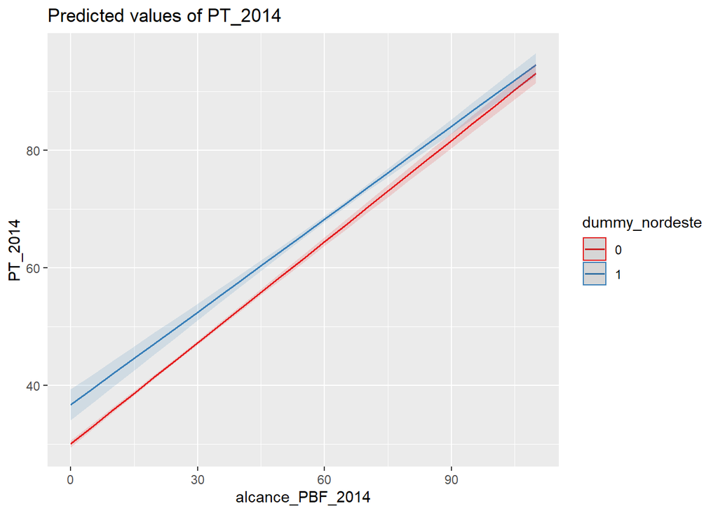

6. Interprete seu gráfico, comparando-o com os resultados da regressão que você obteve no item 4).

Para realizar esta segunda discussão, não haverá exercício propriamente dito. Vamos testar as críticas de Hainmueller, Mummolo e Xu (2019), implementando seus comandos sugeridos, em relação à base que utilizamos aula passada. A ideia é reavaliarmos se nossos resultados obtidos se sustentam com a crítica feita por eles a trabalhos que utilizam modelos interativos. Suponha, então, que tenhamos o mesmo modelo da aula passada, que é algo um pouco fora do usual quando se pensa um experimento: a cidade estar no Nordeste é o tratamento e a cobertura do Bolsa Família, a variável moderadora. Isto não é preciso do ponto de vista metodológico porque o tratamento precisaria ser aleatório e no caso não é. Fazemos isso pelo exercício apenas, já que precisaríamos de uma dummy para facilitar a noção de tratamento. Assim, nosso “experimento” aqui é: se alocássemos uma cidade no Nordeste (tratamento), teria ela apresentado uma votação maior para o PT do que uma cidade que está fora do Nordeste (controle)?

As duas críticas apontadas pelos autores são: se a relação entre as variáveis não é linear, um modelo linear pode ser usado apenas como uma aproximação linear do que seria o modelo real (p.164). A segunda crítica é que é necessário atentar-se se há common support nos dados quando montamos um modelo, isto né, no caso do nosso exemplo, se existe um número suficiente de casos em que Z=0 e Z=1, se não a conclusão que tiramos do nosso modelo é mera extrapolação.